# Diamonds_and_Price_Predictions

Aniko Lengyel

I loaded the data and looked at the structure.

```
## Classes 'tbl_df', 'tbl' and 'data.frame':    53940 obs. of  10 variables:
##  $ carat  : num  0.23 0.21 0.23 0.29 0.31 0.24 0.24 0.26 0.22 0.23 ...
##  $ cut    : Ord.factor w/ 5 levels "Fair"<"Good"<..: 5 4 2 4 2 3 3 3 1 3 ...
##  $ color  : Ord.factor w/ 7 levels "D"<"E"<"F"<"G"<..: 2 2 2 6 7 7 6 5 2 5 ...
##  $ clarity: Ord.factor w/ 8 levels "I1"<"SI2"<"SI1"<..: 2 3 5 4 2 6 7 3 4 5 ...
##  $ depth  : num  61.5 59.8 56.9 62.4 63.3 62.8 62.3 61.9 65.1 59.4 ...
##  $ table  : num  55 61 65 58 58 57 57 55 61 61 ...
##  $ price  : int  326 326 327 334 335 336 336 337 337 338 ...
##  $ x      : num  3.95 3.89 4.05 4.2 4.34 3.94 3.95 4.07 3.87 4 ...
##  $ y      : num  3.98 3.84 4.07 4.23 4.35 3.96 3.98 4.11 3.78 4.05 ...
##  $ z      : num  2.43 2.31 2.31 2.63 2.75 2.48 2.47 2.53 2.49 2.39 ...
```

```
## # A tibble: 6 x 10
##   carat cut       color clarity depth table price     x     y     z
##   <dbl> <ord>     <ord> <ord>   <dbl> <dbl> <int> <dbl> <dbl> <dbl>
## 1 0.230 Ideal     E     SI2      61.5  55.0   326  3.95  3.98  2.43
## 2 0.210 Premium   E     SI1      59.8  61.0   326  3.89  3.84  2.31
## 3 0.230 Good      E     VS1      56.9  65.0   327  4.05  4.07  2.31
## 4 0.290 Premium   I     VS2      62.4  58.0   334  4.20  4.23  2.63
## 5 0.310 Good      J     SI2      63.3  58.0   335  4.34  4.35  2.75
## 6 0.240 Very Good J     VVS2     62.8  57.0   336  3.94  3.96  2.48
```

“In this case, we can use a variety of diamond characteristics to help us figure out whether the price advertised for any given diamond is reasonable or a rip-off.”

I used scatteplots to examine two variables, price(y) and carat_weight(x) I limited the x-axis and y-axis to exclude the top 1% of values.

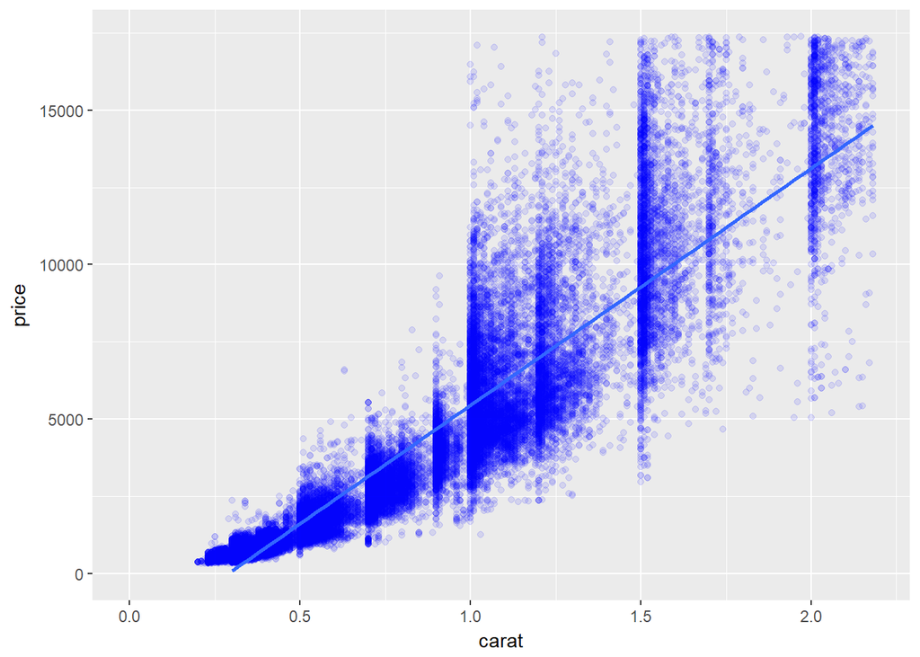

I created two plots, following the instructions:

“Create two histograms of the price variable and place them side by side on one output image.

We’ve put some code below to get you started.

The first plot should be a histogram of price and the second plot should transform the price variable using log10.“”

I created appropriate bin widths for each plot and added a title and filled the plots with color.

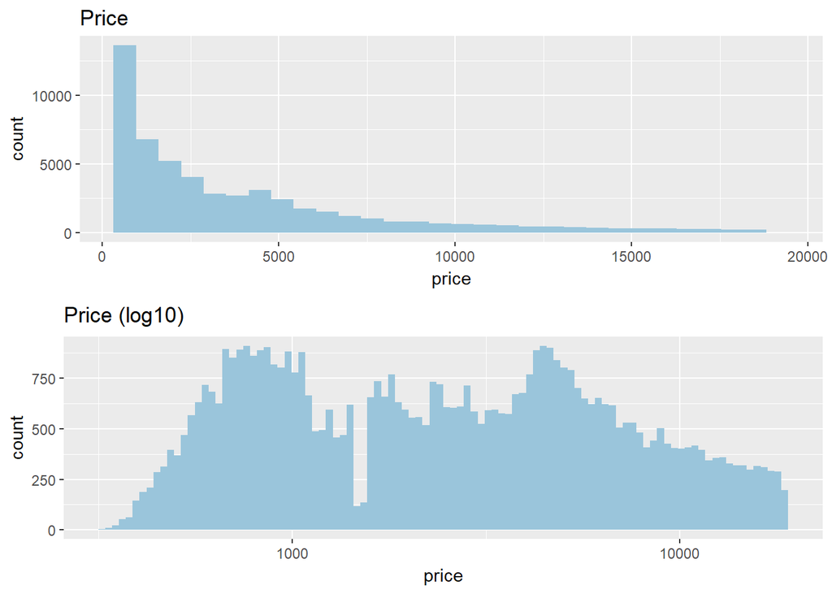

The function cuberoot_trans transforms the x-axis. Transform function takes a cuberoot of a variable, inverse function undoes the results of the transform function. We also added limits, breaks and title to make the plots better readable.

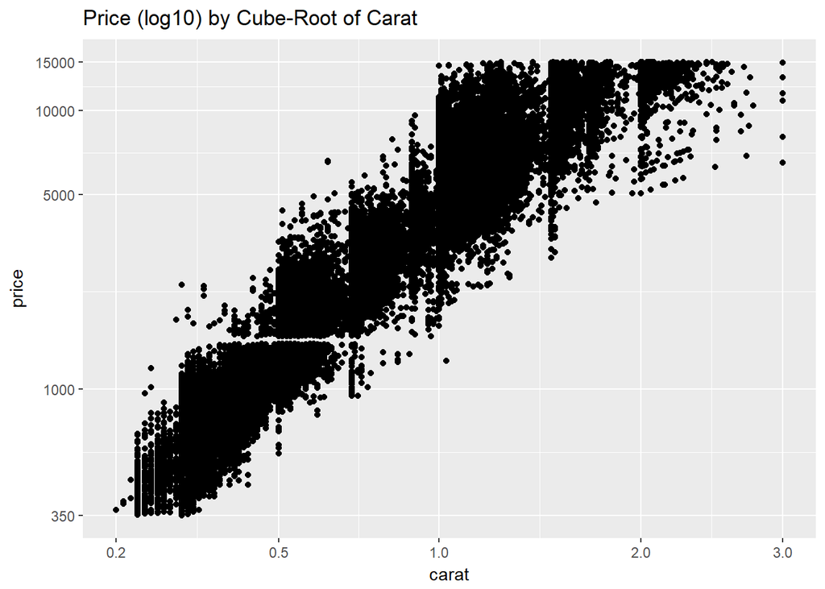

I added a color layer to grop the diamonds by clarity.

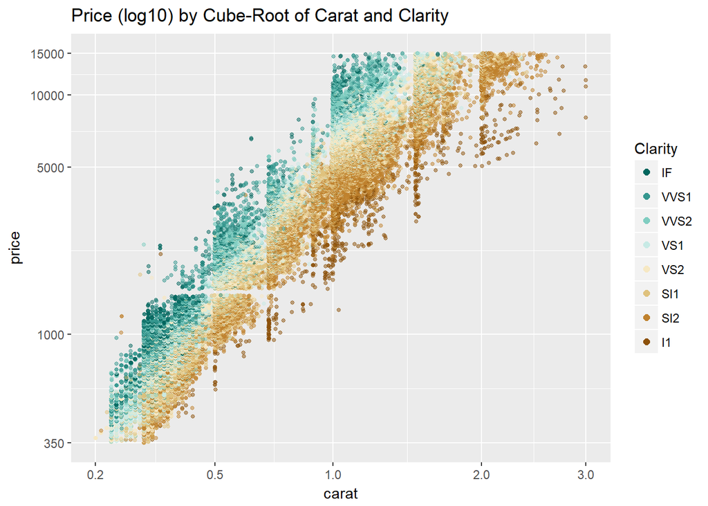

Another color layer to mark the diamonds by cut.

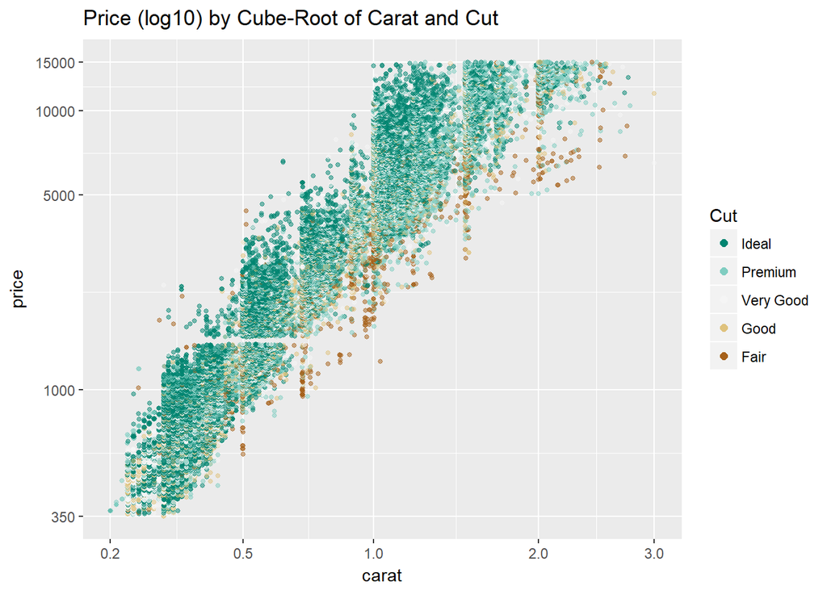

Another colot layer to gorp the diamonds by color.

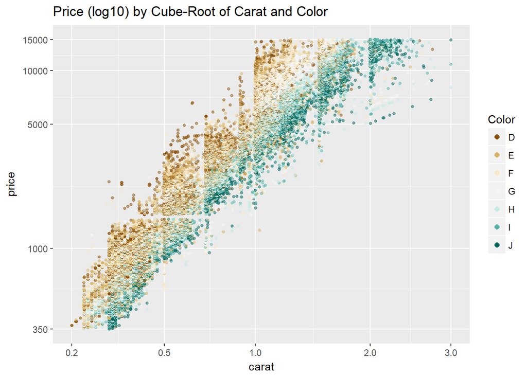

We built a linear model to predict the diamond price based on different variables.

```
##
## Calls:
## m1: lm(formula = I(log(price)) ~ I(carat^(1/3)), data = diamonds)
## m2: lm(formula = I(log(price)) ~ I(carat^(1/3)) + carat, data = diamonds)
## m3: lm(formula = I(log(price)) ~ I(carat^(1/3)) + carat + cut, data = diamonds)
## m4: lm(formula = I(log(price)) ~ I(carat^(1/3)) + carat + cut + color,
##     data = diamonds)
## m5: lm(formula = I(log(price)) ~ I(carat^(1/3)) + carat + cut + color +
##     clarity, data = diamonds)
##
## ============================================================================================
##                        m1             m2             m3             m4            m5
## --------------------------------------------------------------------------------------------
##   (Intercept)          2.821***       1.039***       0.874***      0.932***       0.415***
##                       (0.006)        (0.019)        (0.019)       (0.017)        (0.010)
##   I(carat^(1/3))       5.558***       8.568***       8.703***      8.438***       9.144***
##                       (0.007)        (0.032)        (0.031)       (0.028)        (0.016)
##   carat                              -1.137***      -1.163***     -0.992***      -1.093***
##                                      (0.012)        (0.011)       (0.010)        (0.006)
##   cut: .L                                            0.224***      0.224***       0.120***
##                                                     (0.004)       (0.004)        (0.002)
##   cut: .Q                                           -0.062***     -0.062***      -0.031***
##                                                     (0.004)       (0.003)        (0.002)
##   cut: .C                                            0.051***      0.052***       0.014***
##                                                     (0.003)       (0.003)        (0.002)
##   cut: ^4                                            0.018***      0.018***      -0.002
##                                                     (0.003)       (0.002)        (0.001)
##   color: .L                                                       -0.373***      -0.441***
##                                                                   (0.003)        (0.002)
##   color: .Q                                                       -0.129***      -0.093***
##                                                                   (0.003)        (0.002)
##   color: .C                                                        0.001         -0.013***
##                                                                   (0.003)        (0.002)
##   color: ^4                                                        0.029***       0.012***
##                                                                   (0.003)        (0.002)
##   color: ^5                                                       -0.016***      -0.003*
##                                                                   (0.003)        (0.001)
##   color: ^6                                                       -0.023***       0.001
##                                                                   (0.002)        (0.001)
##   clarity: .L                                                                     0.907***
```

[output cut: 10 more lines]

```
##                                                                                  (0.002)
##   clarity: ^7                                                                     0.032***
##                                                                                  (0.001)
## --------------------------------------------------------------------------------------------
##   R-squared            0.924          0.935          0.939         0.951          0.984
##   adj. R-squared       0.924          0.935          0.939         0.951          0.984
##   sigma                0.280          0.259          0.250         0.224          0.129
##   F               652012.063     387489.366     138654.523     87959.467     173791.084
##   p                    0.000          0.000          0.000         0.000          0.000
##   Log-likelihood   -7962.499      -3631.319      -1837.416      4235.240      34091.272
##   Deviance          4242.831       3613.360       3380.837      2699.212        892.214
##   AIC              15930.999       7270.637       3690.832     -8442.481     -68140.544
##   BIC              15957.685       7306.220       3761.997     -8317.942     -67953.736
##   N                53940          53940          53940         53940          53940
## ============================================================================================
```